# SWNS/BoF Herring MSE MP Testing Results

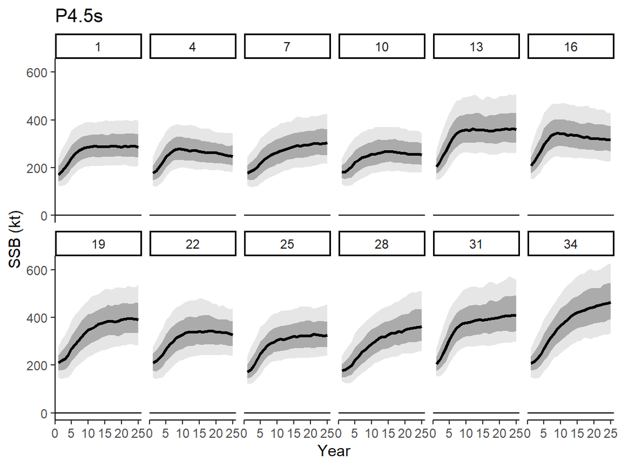

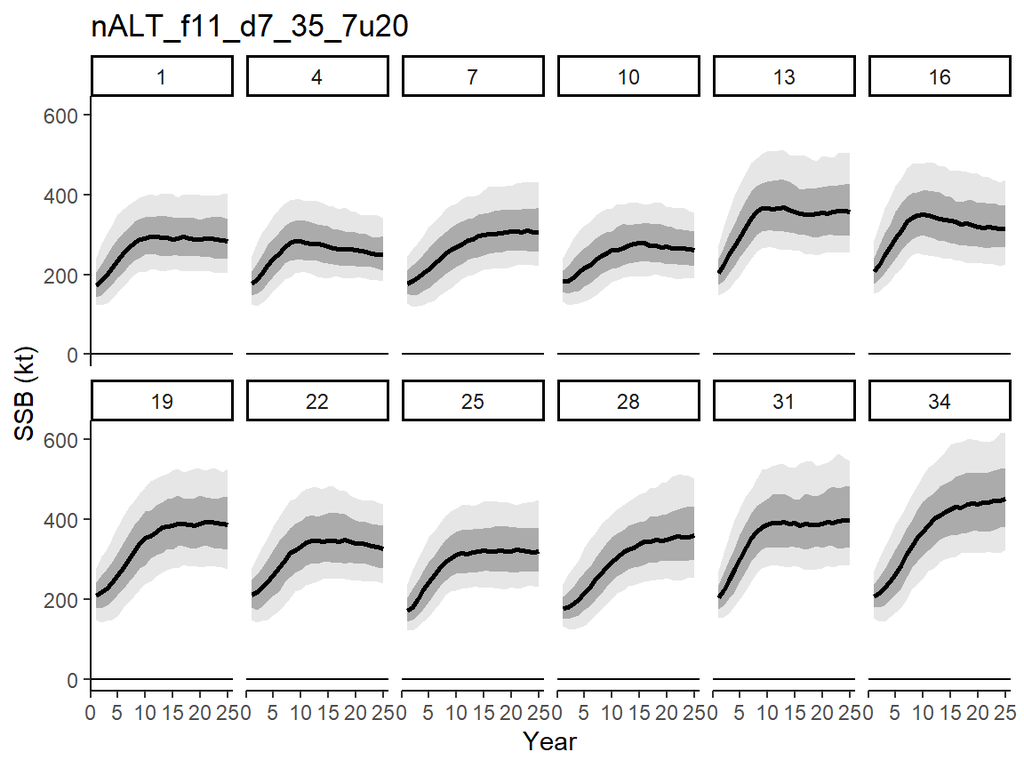

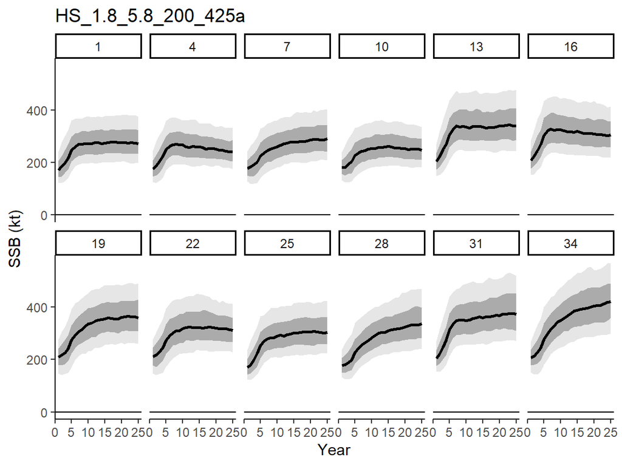

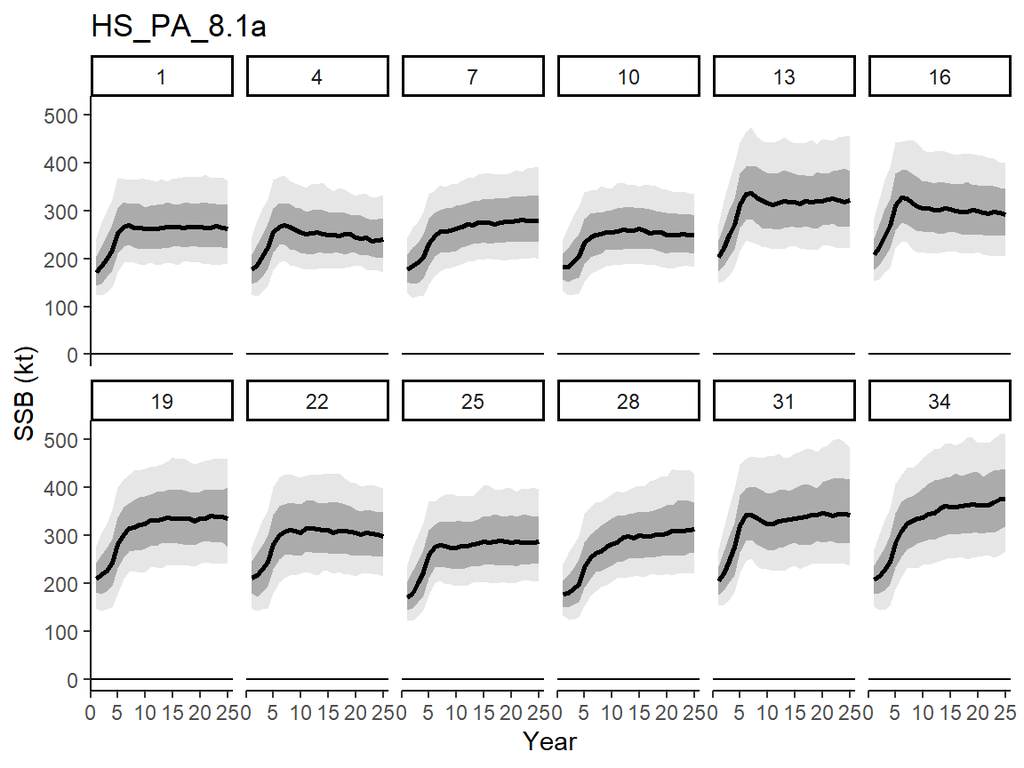

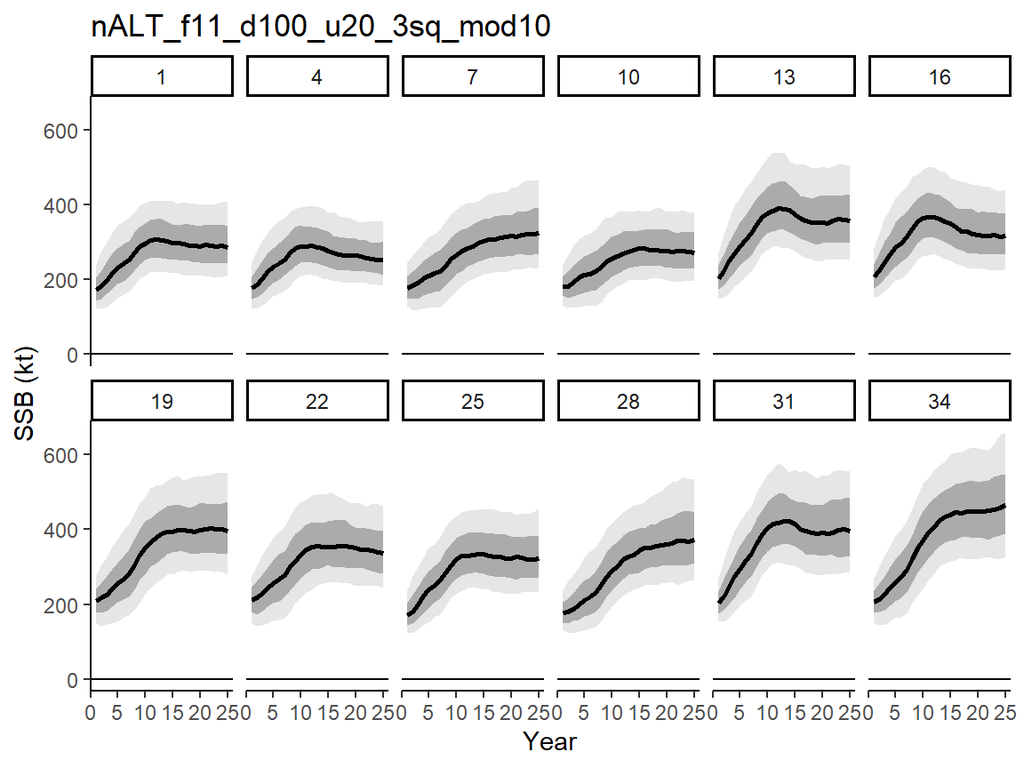

###### Failing MPs

Thick black line = median across all simulations  
Grey shading = 10<sup>th</sup>, 25<sup>th</sup>, 75<sup>th</sup>, and 90<sup>th</sup> percentiles across all simulations

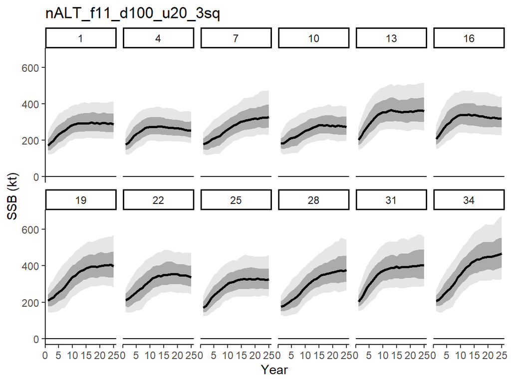

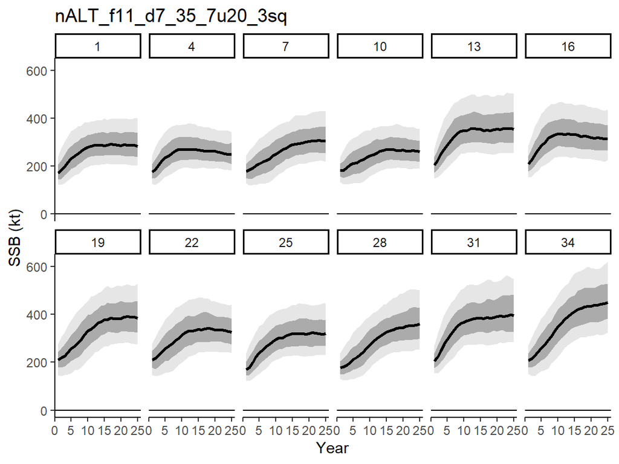

##### Acoustic Index

###### Passing MPs

Thick black line = median across all simulations

Grey shading = 10<sup>th</sup>, 25<sup>th</sup>, 75<sup>th</sup>, and 90<sup>th</sup> percentiles across all simulations

Blue Line = Median 3-yr moving average acoustic index (Unfished beginning in projection year 1)=

Red Line = LRP (mean of 2005-2010)

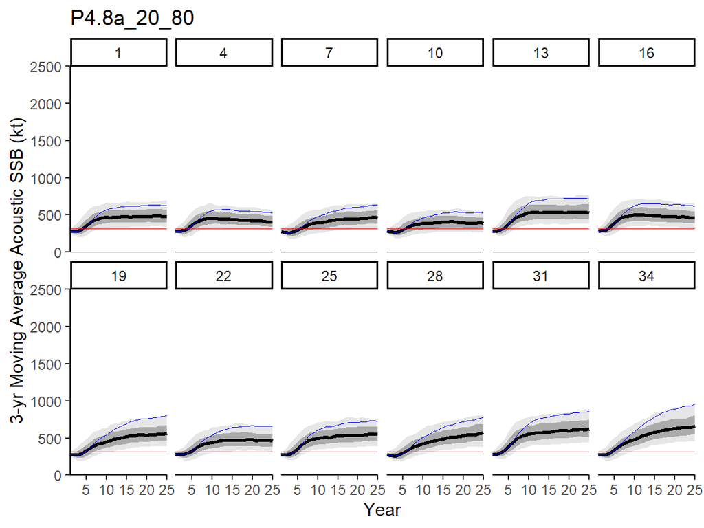

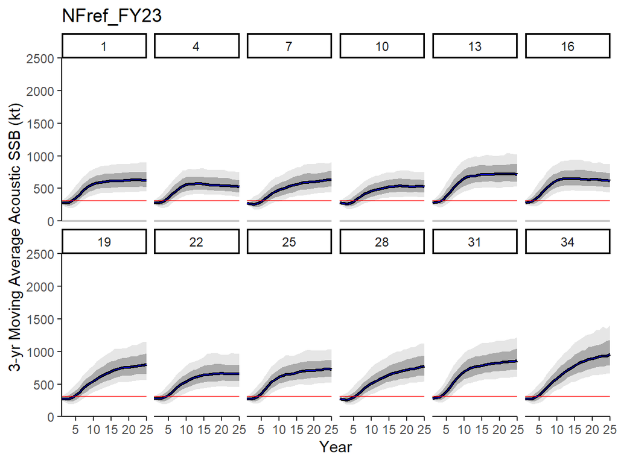

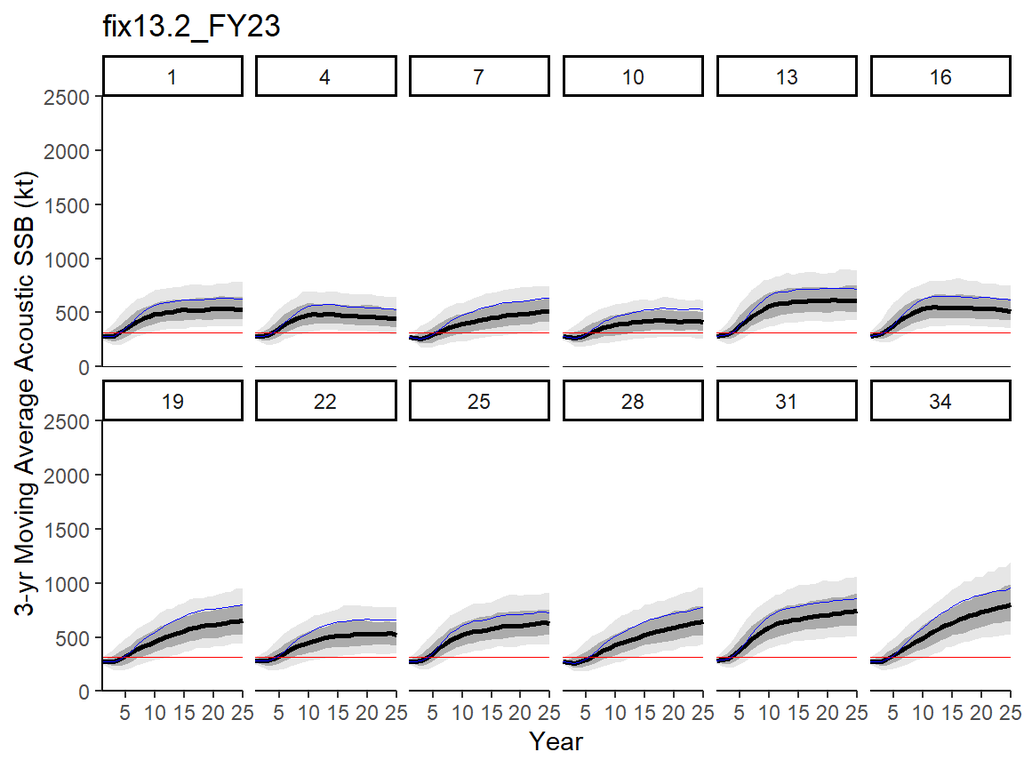

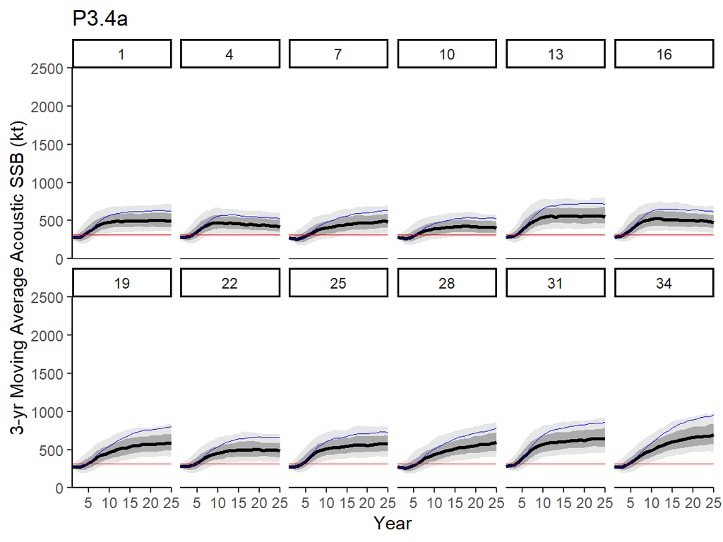

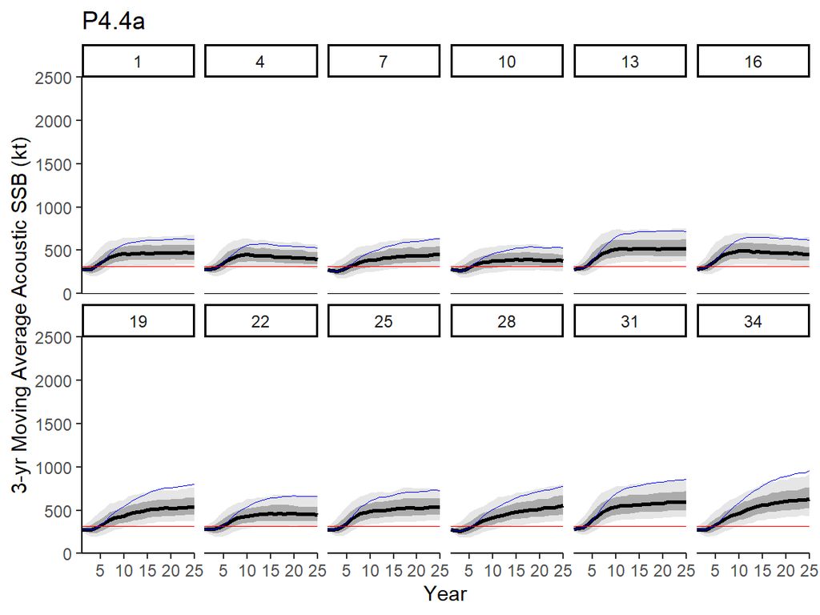

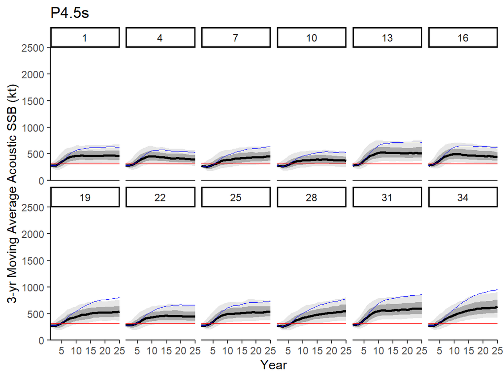

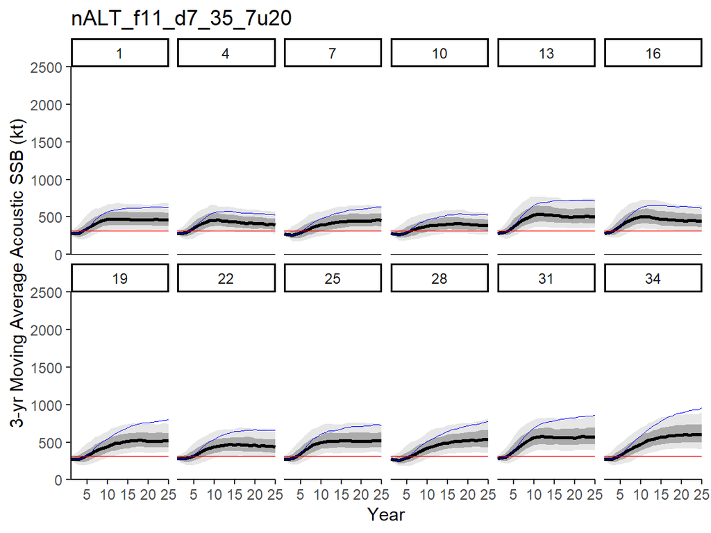

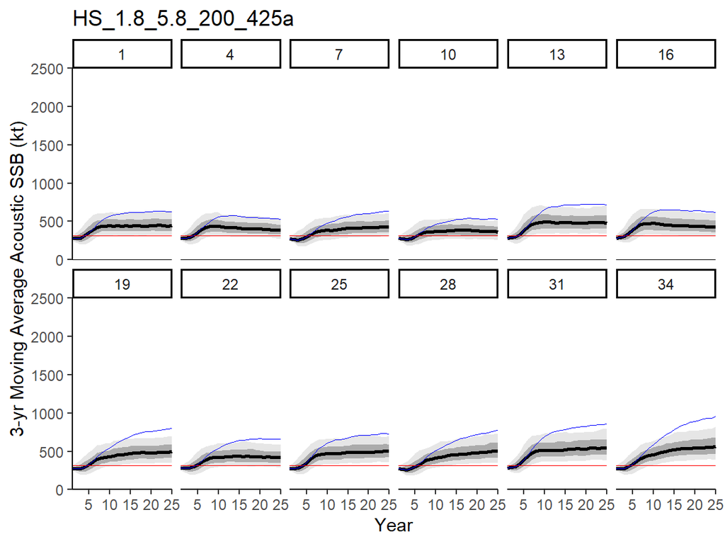

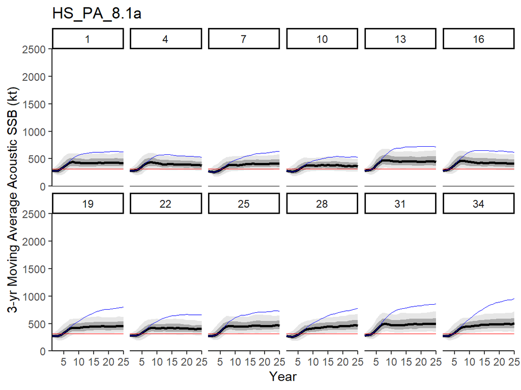

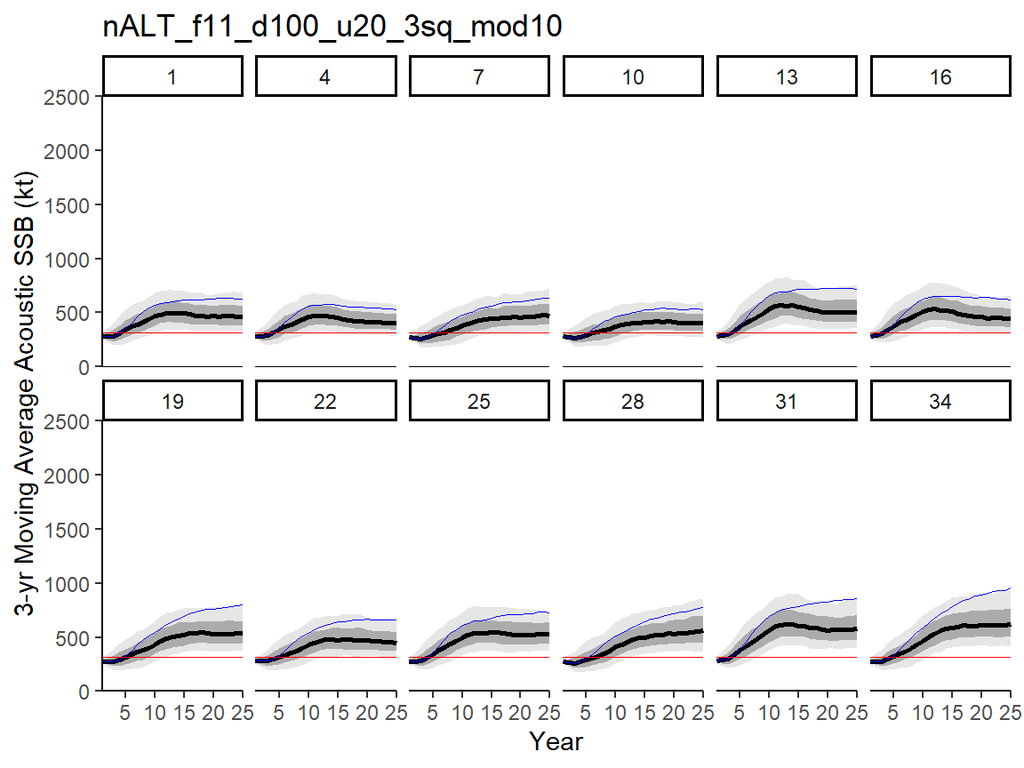

###### Failing MPs

Thick black line = median across all simulations

Grey shading = 10<sup>th</sup>, 25<sup>th</sup>, 75<sup>th</sup>, and 90<sup>th</sup> percentiles across all simulations

Blue Line = Median 3-yr moving average acoustic index (Unfished beginning in projection year 1)

Red Line = LRP (mean of 2005-2010)

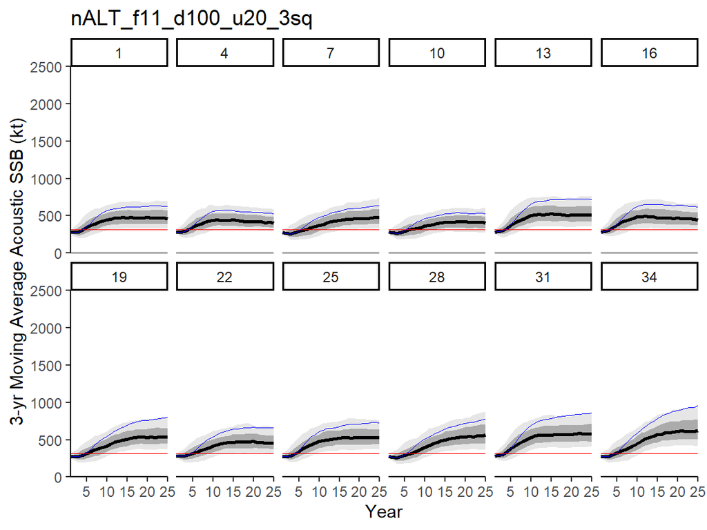

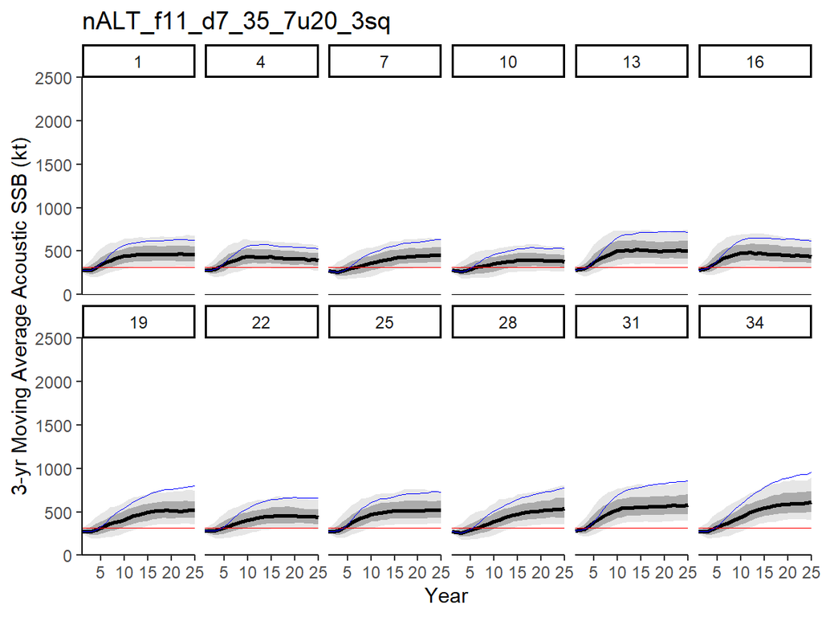

##### Projected Catch

###### Passing MPs

Red line = median across all simulations  
Grey shading = 10<sup>th</sup>, 25<sup>th</sup>, 75<sup>th</sup>, and 90<sup>th</sup> percentiles across all simulations  
Blue Line = Year 10 of the projection when passing MPs must be above LRP for OM10  
All Projections are for OM10 only.

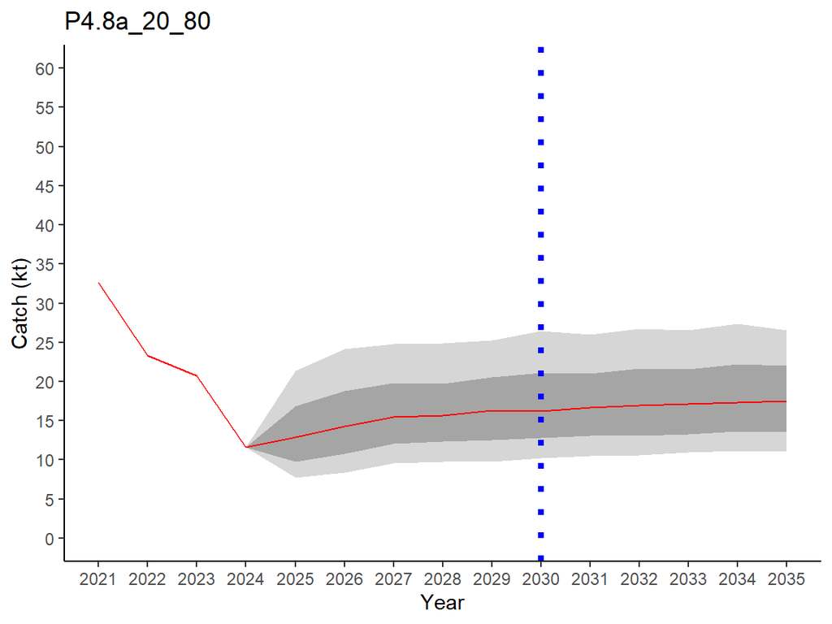

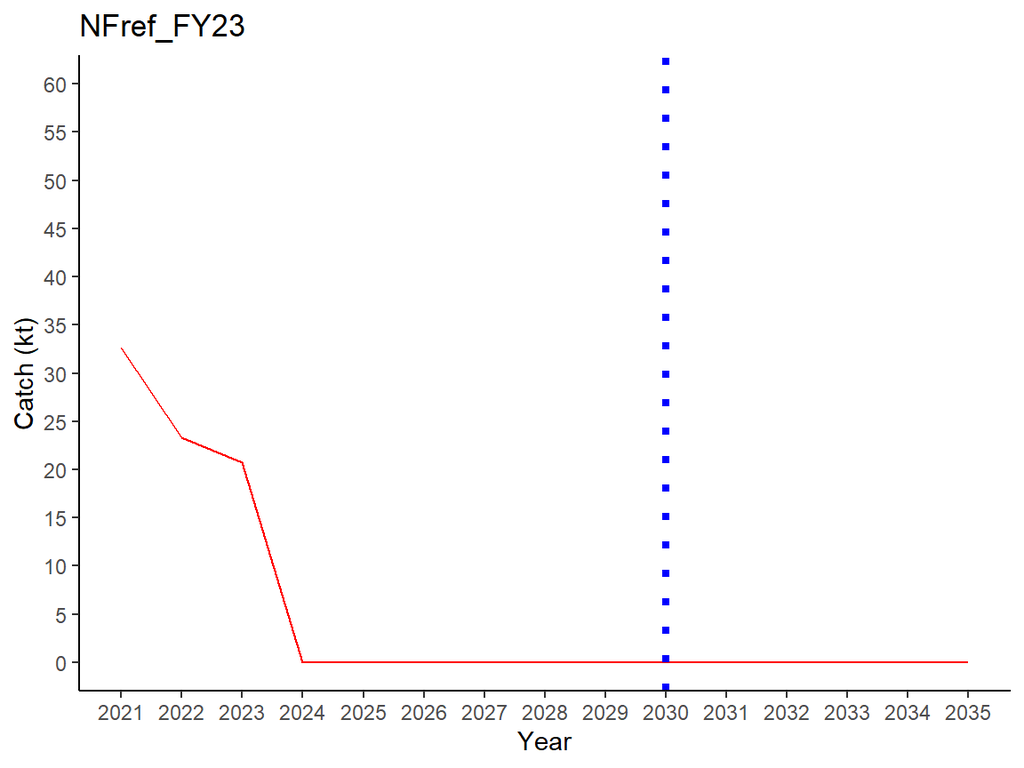

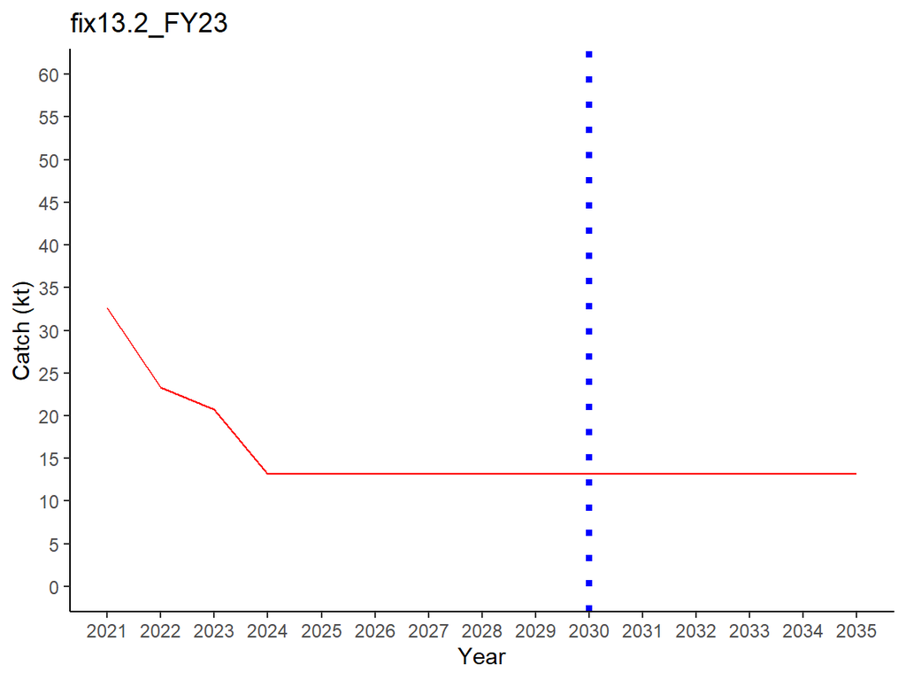

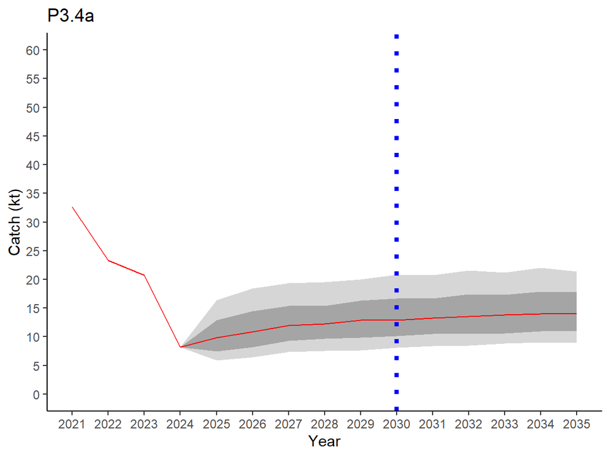

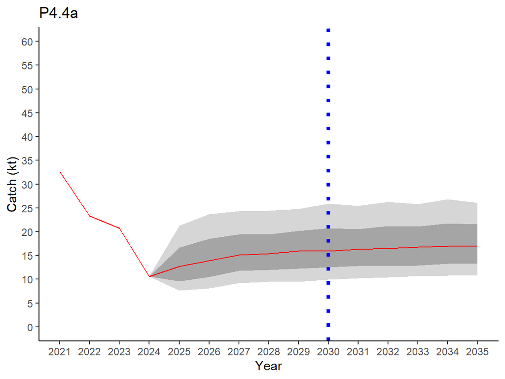

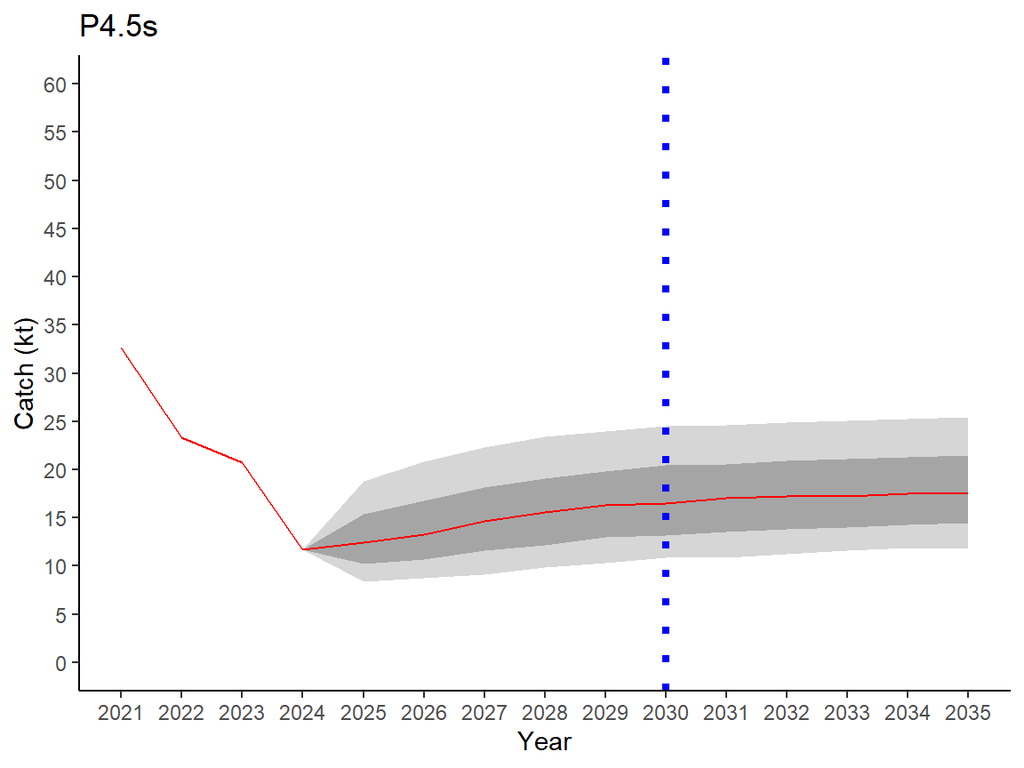

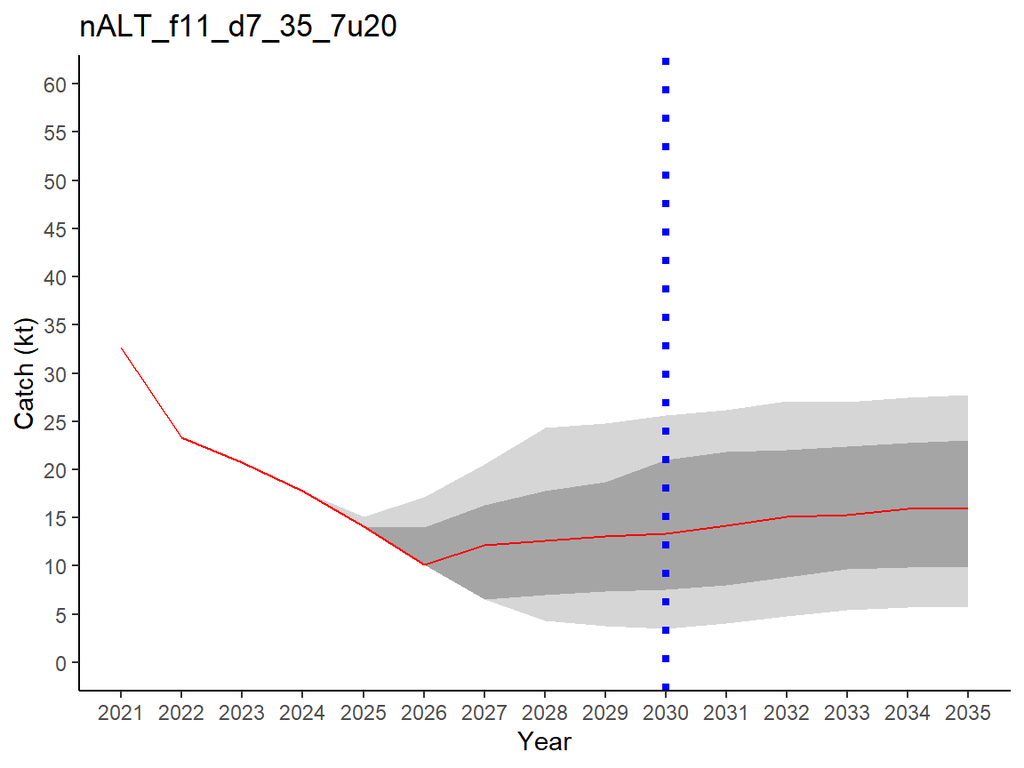

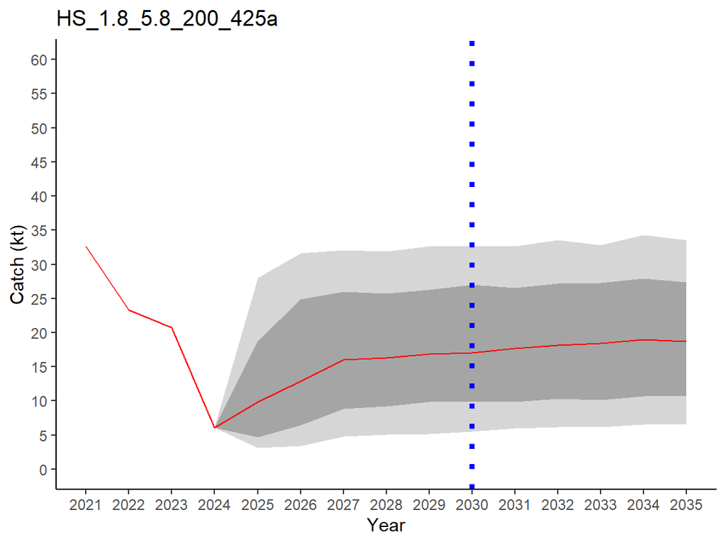

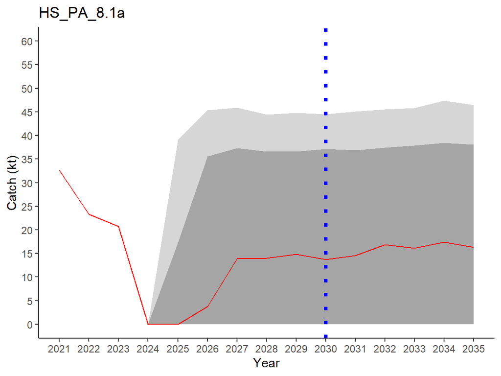

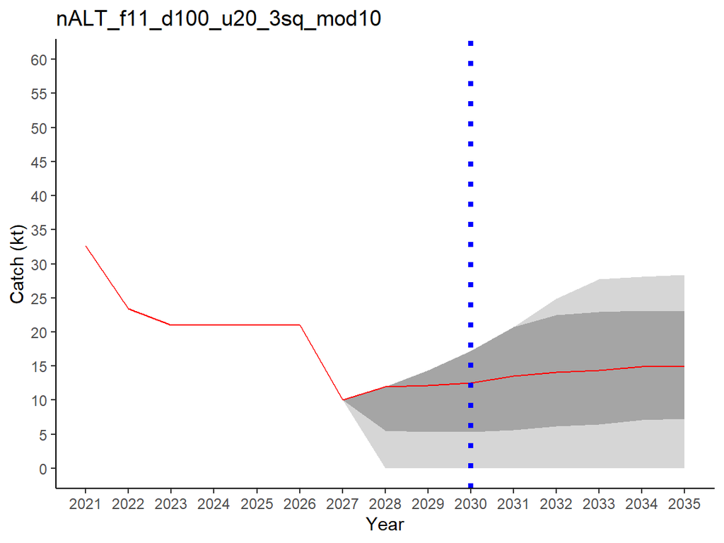

###### Failing MPs

Red line = median across all simulations  
Grey shading = 10<sup>th</sup>, 25<sup>th</sup>, 75<sup>th</sup>, and 90<sup>th</sup> percentiles across all simulations  
Blue Line = Year 10 of the projection when passing MPs must be above LRP for OM10  
All Projections are for OM10 only.

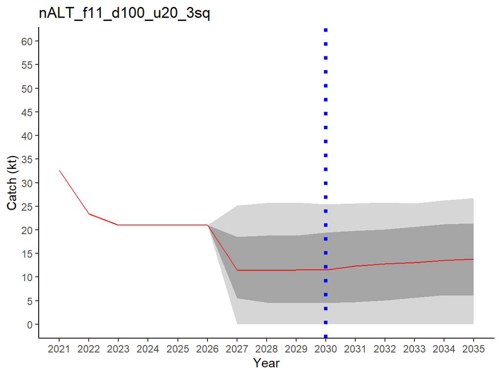

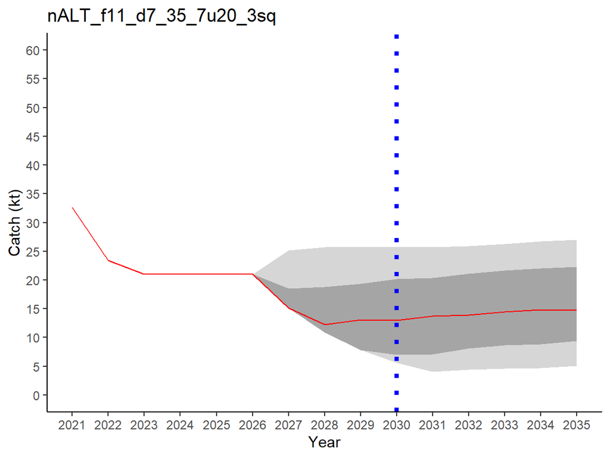

##### Catch Worm Plots

###### Passing MPs

Different coloured line = Random selected catches from MP from various simulations  
All Projections are for OM10 only.

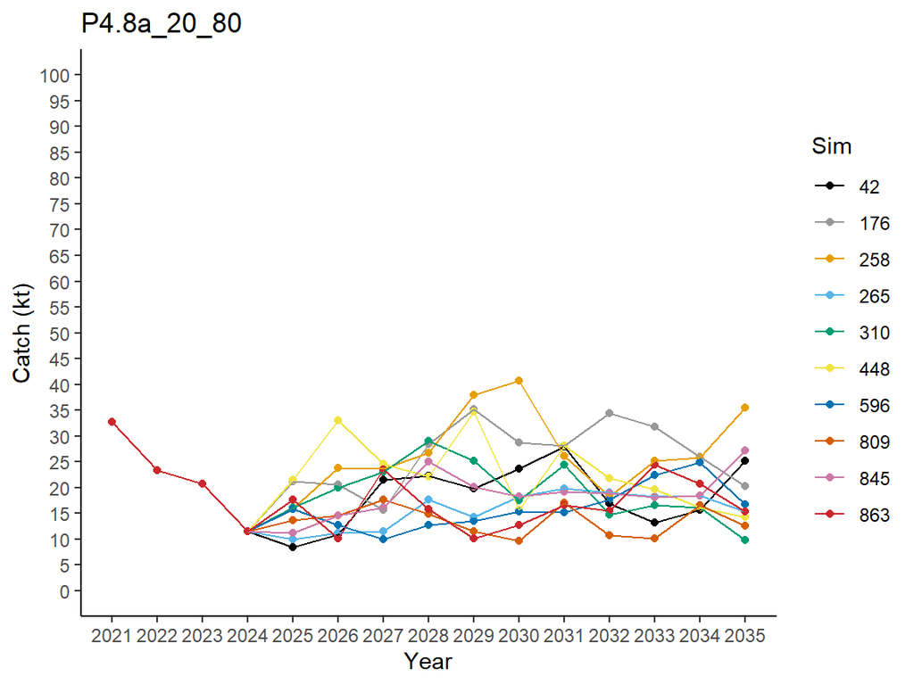

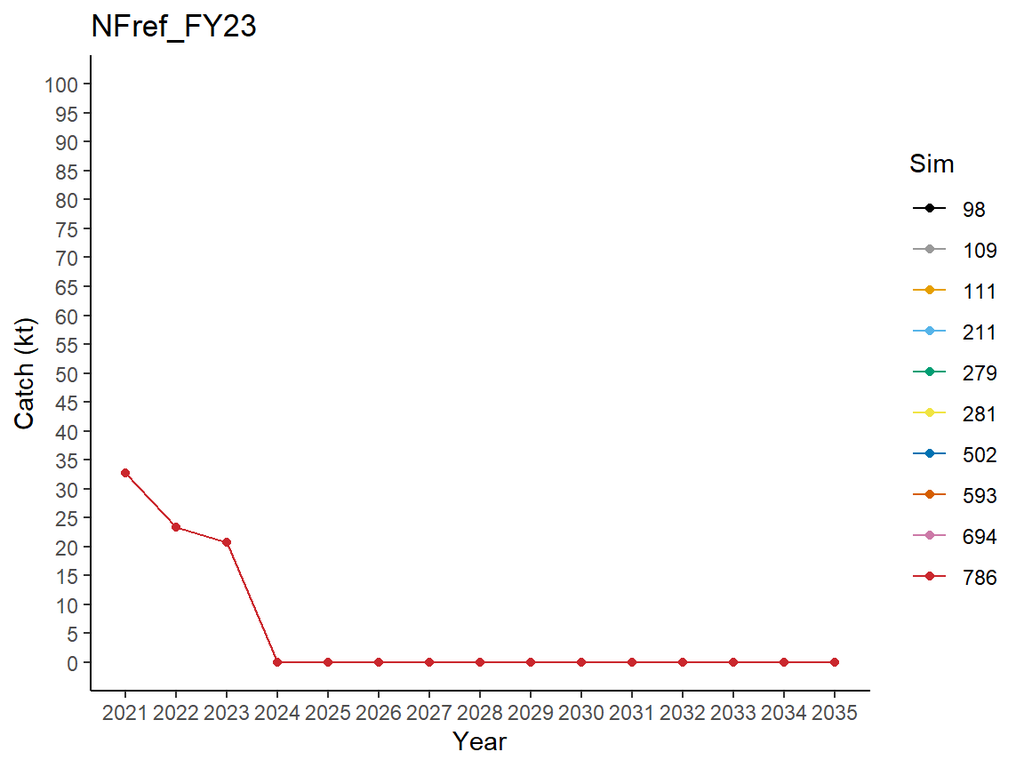

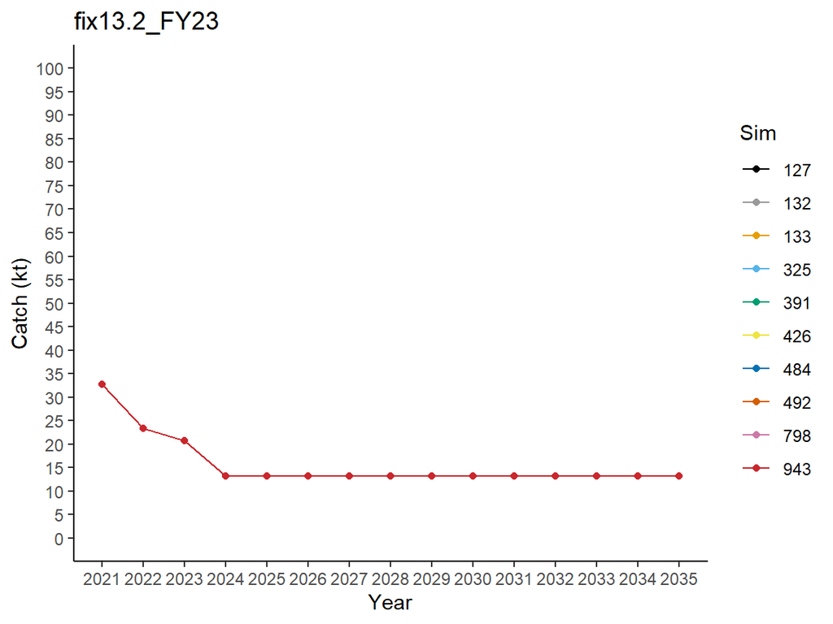

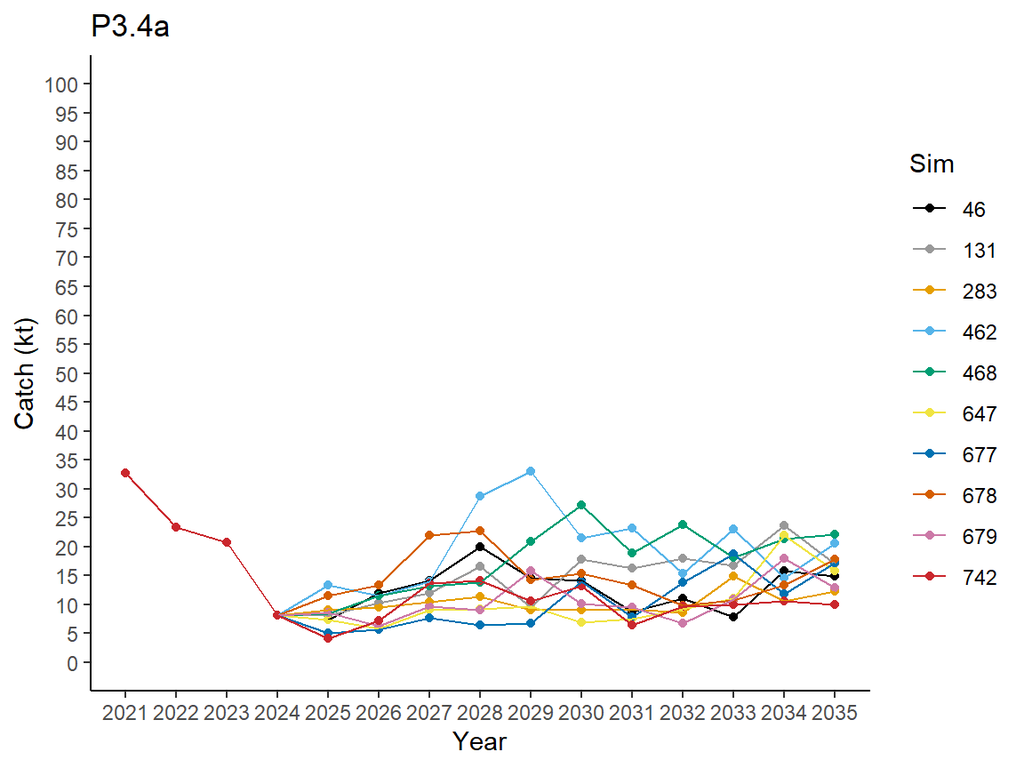

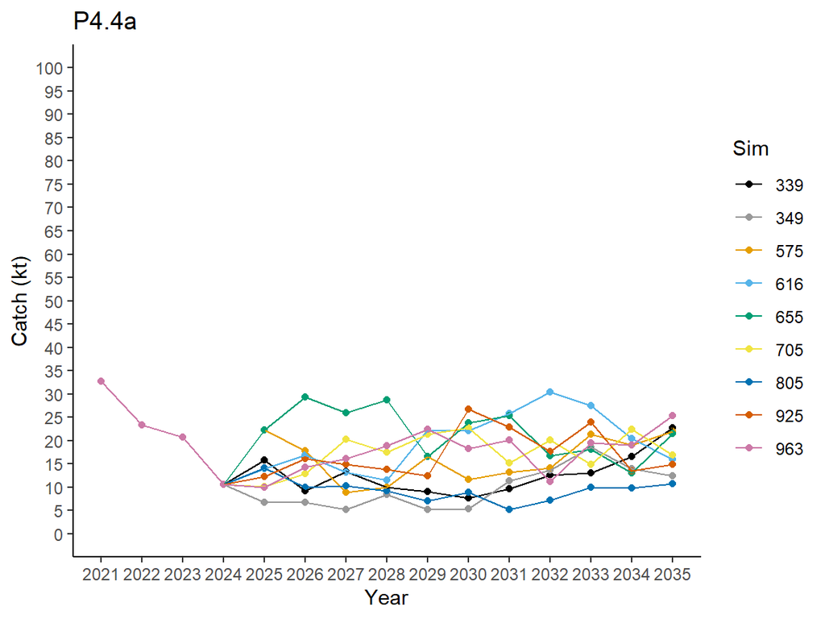

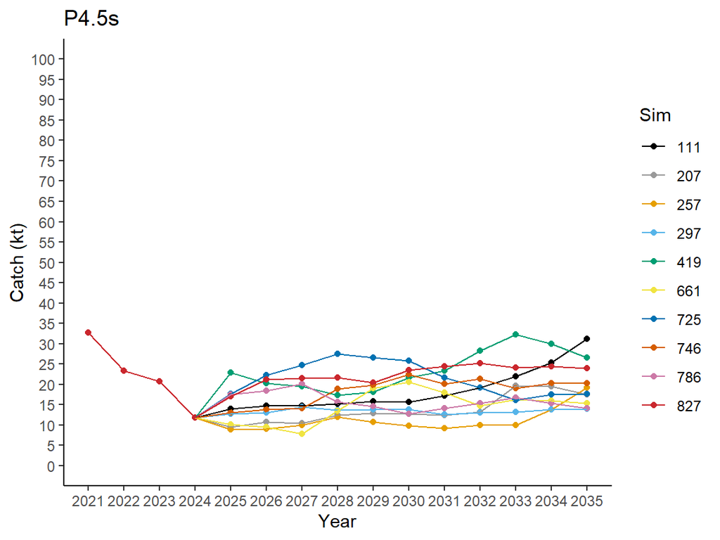

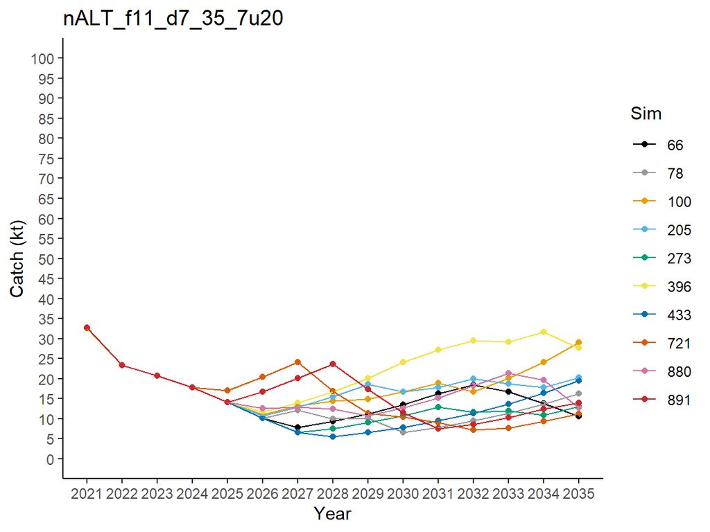

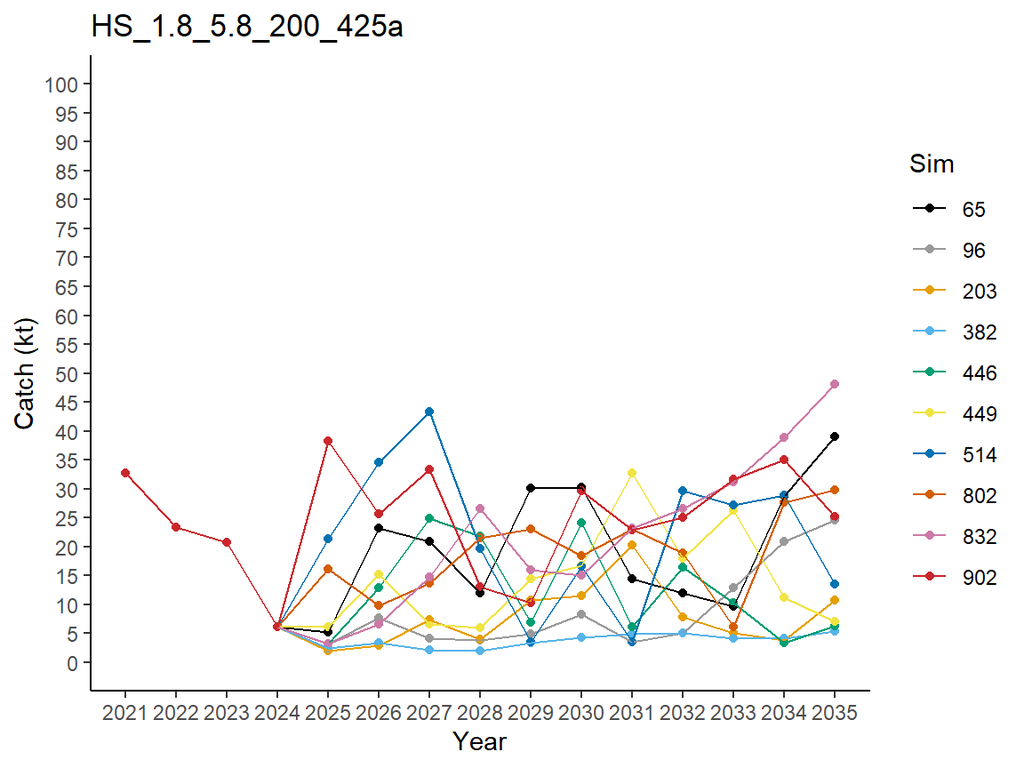

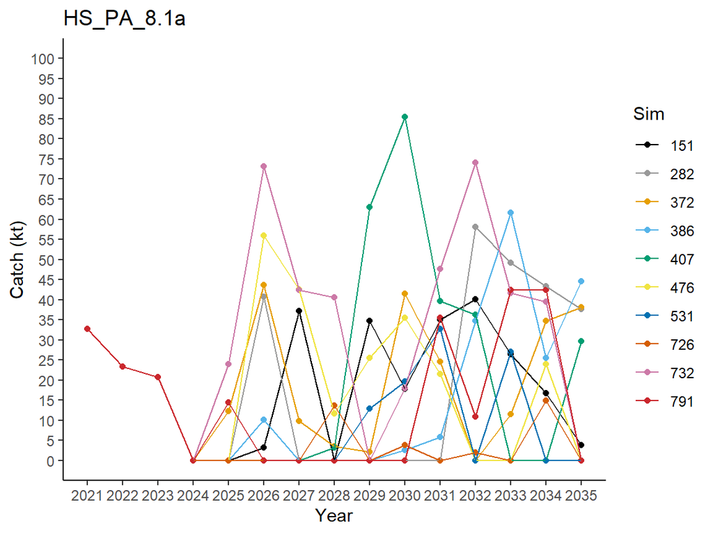

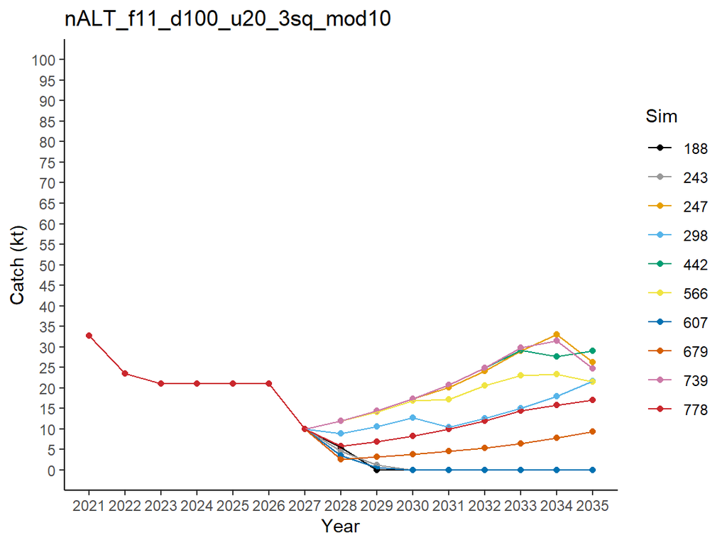

###### Failing MPs

Different coloured line = Random selected catches from MP from various simulations  
All Projections are for OM10 only.

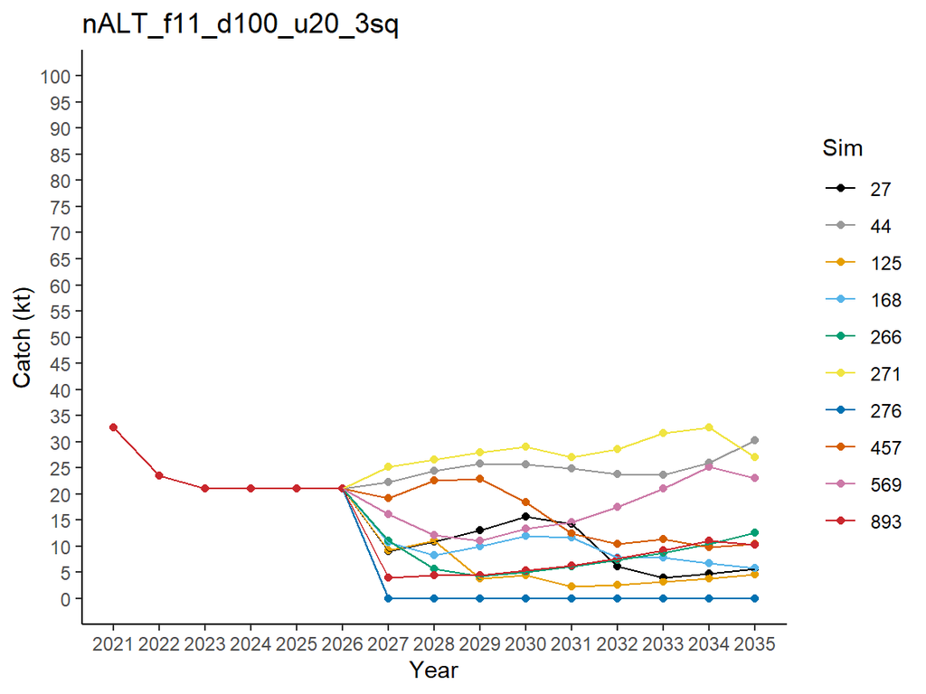

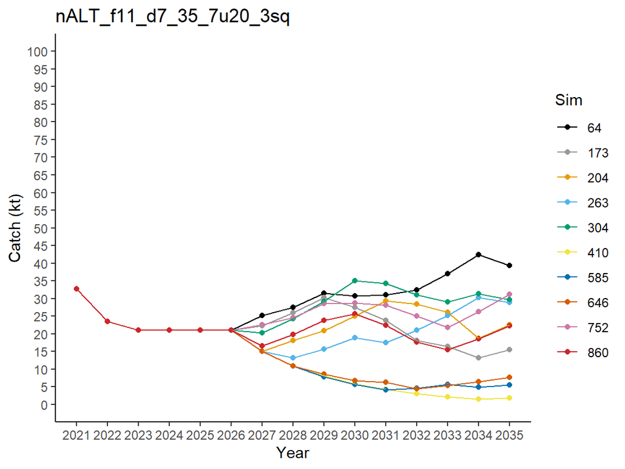

##### Hybrid Worm Plots

###### Passing MPs

Different coloured line = Random selected catches from MP from various simulations  
Grey shading = 10<sup>th</sup>, 25<sup>th</sup>, 75<sup>th</sup>, and 90<sup>th</sup> percentiles across all simulations  
All Projections are for OM10 only.

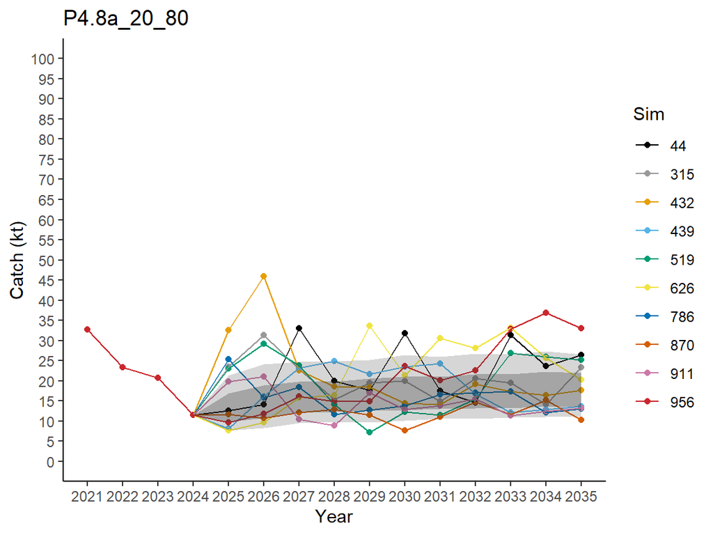

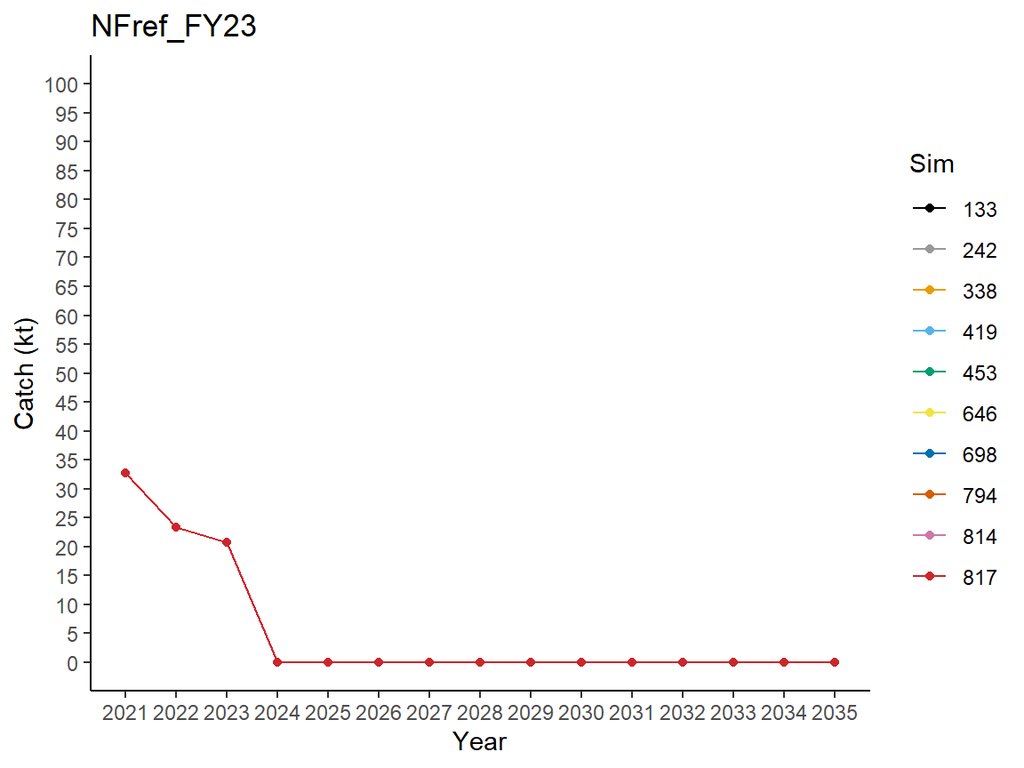

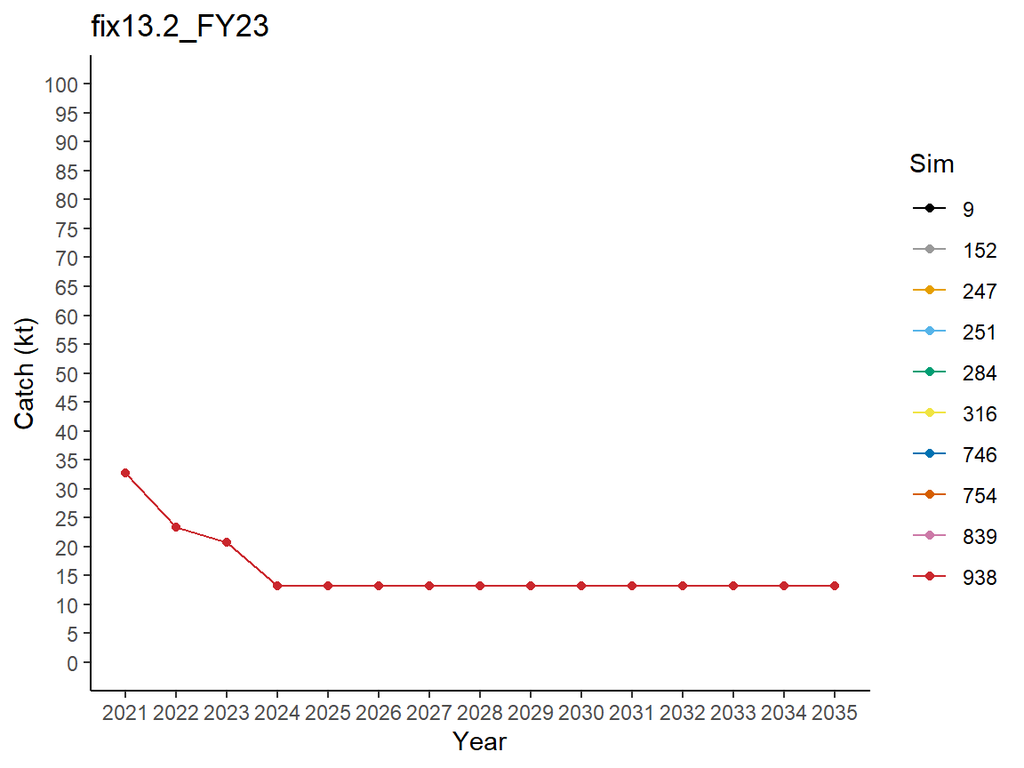

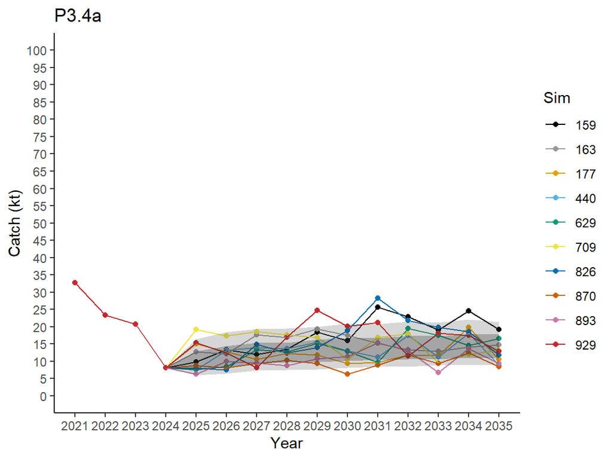

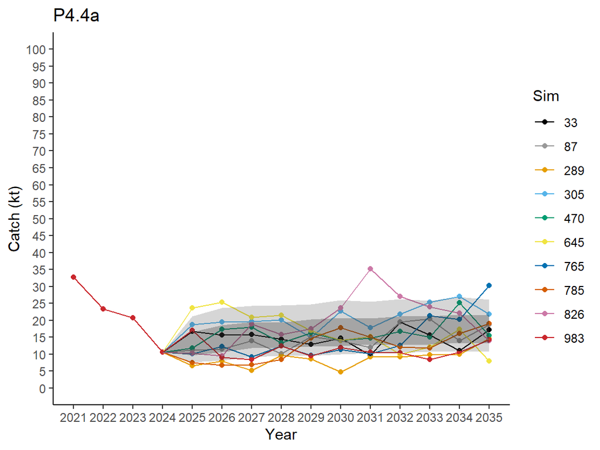

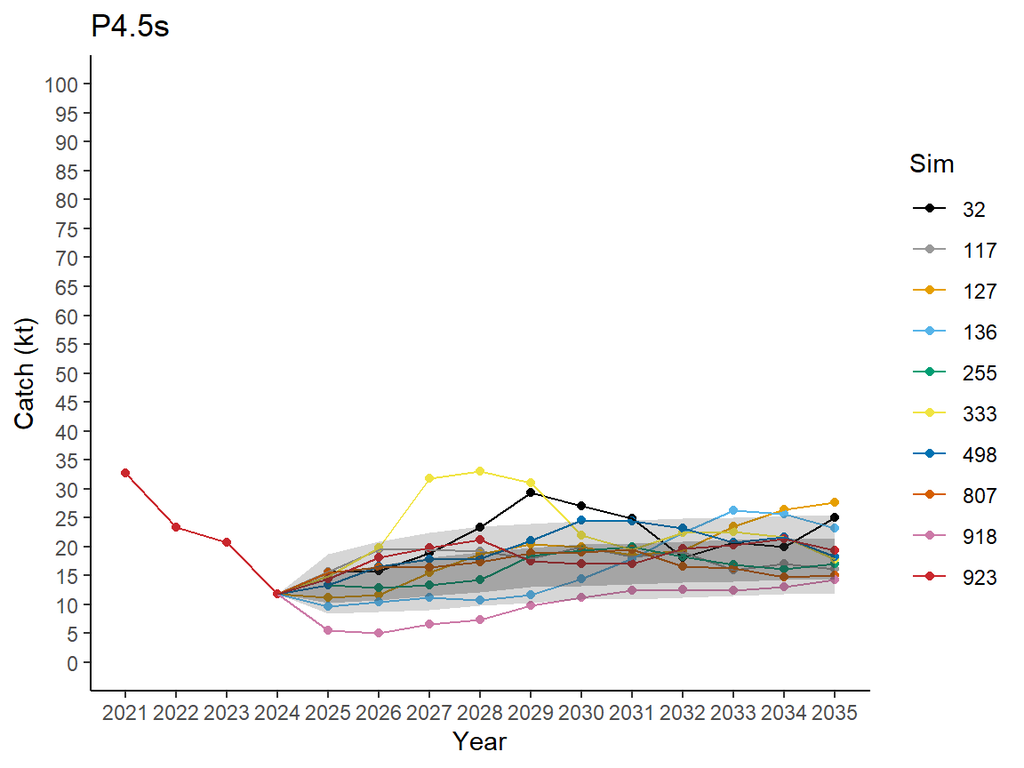

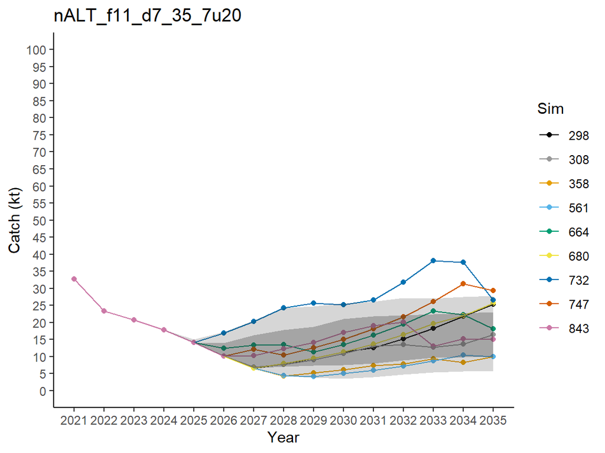

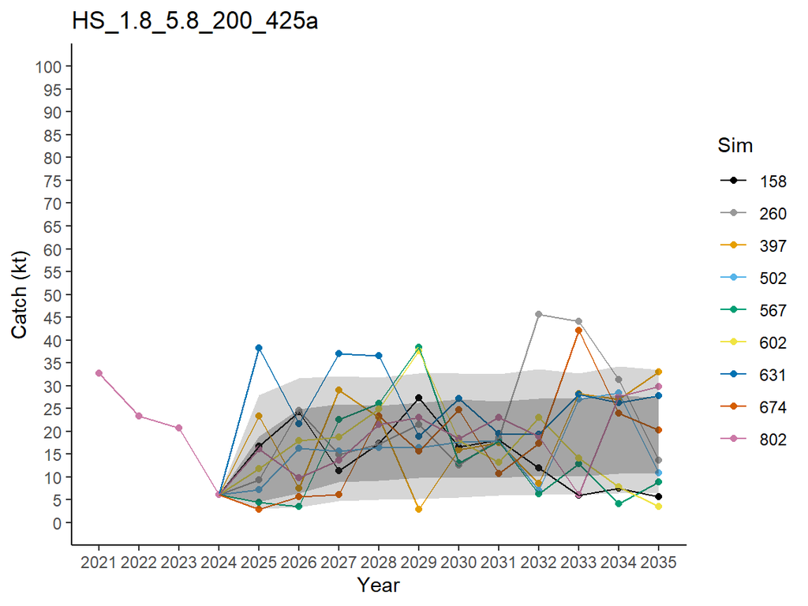

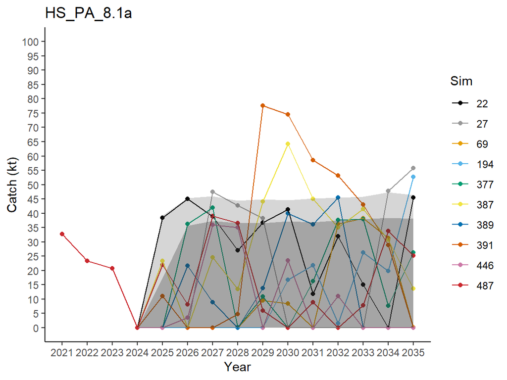

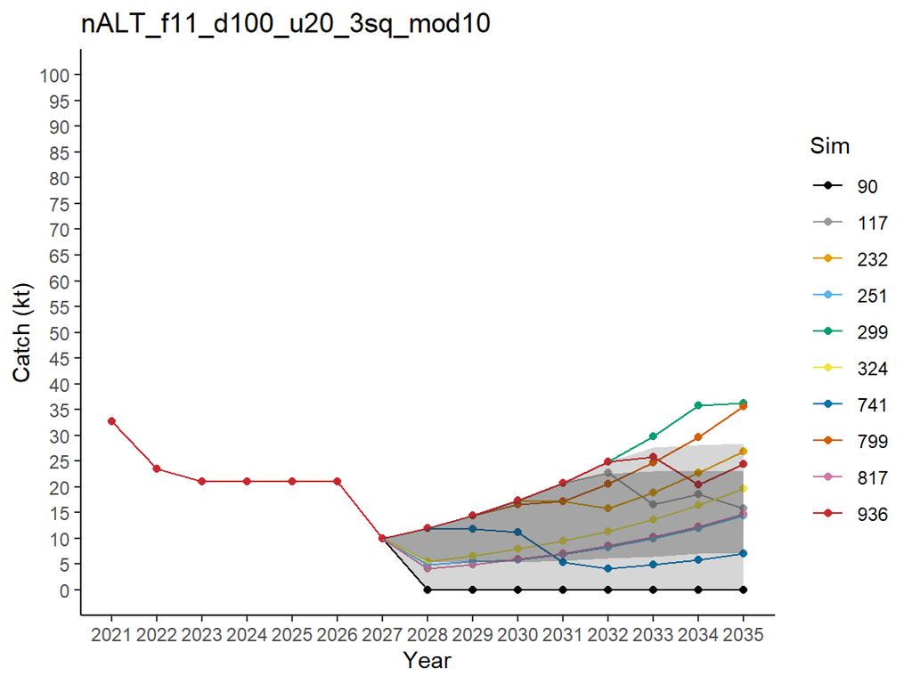

###### Failing MPs

Different coloured line = Random selected catches from MP from various simulations  
Grey shading = 10<sup>th</sup>, 25<sup>th</sup>, 75<sup>th</sup>, and 90<sup>th</sup> percentiles across all simulations  
All Projections are for OM10 only.

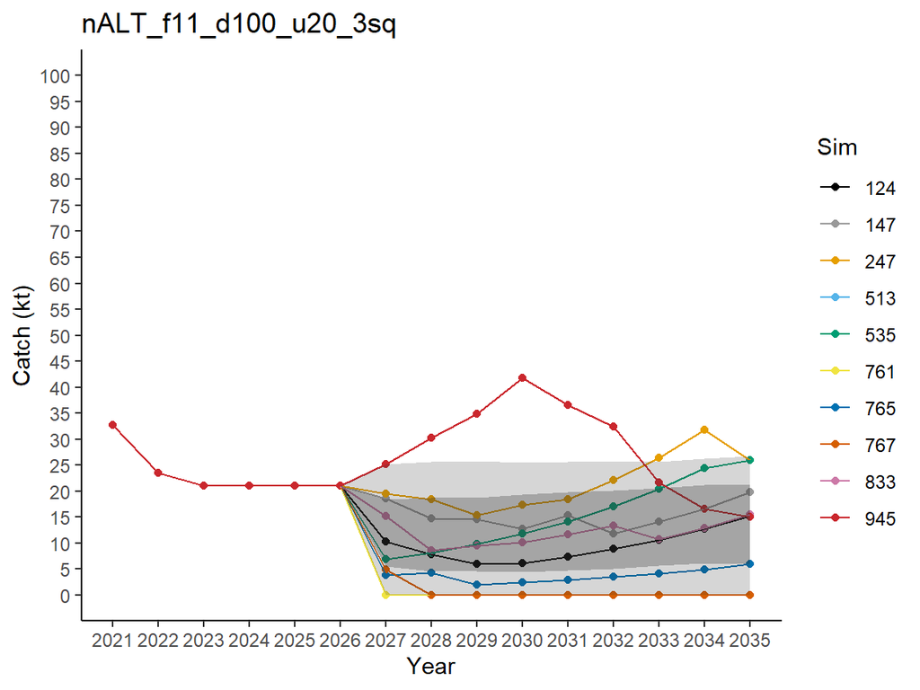

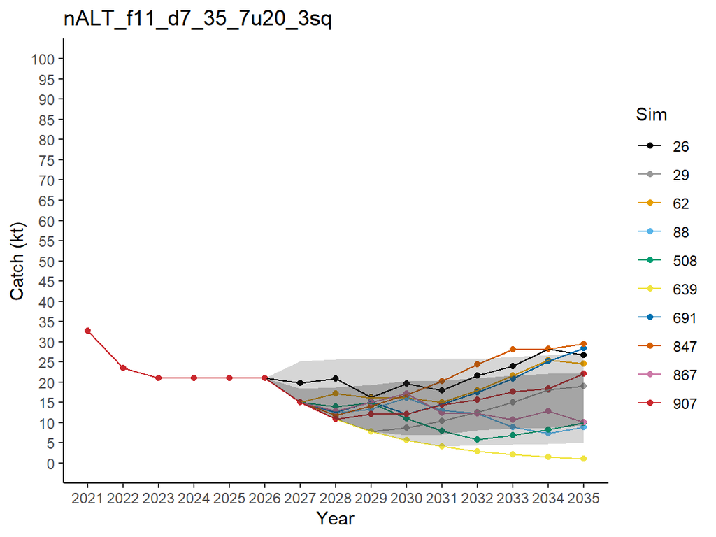

#### Performance Metric Plots

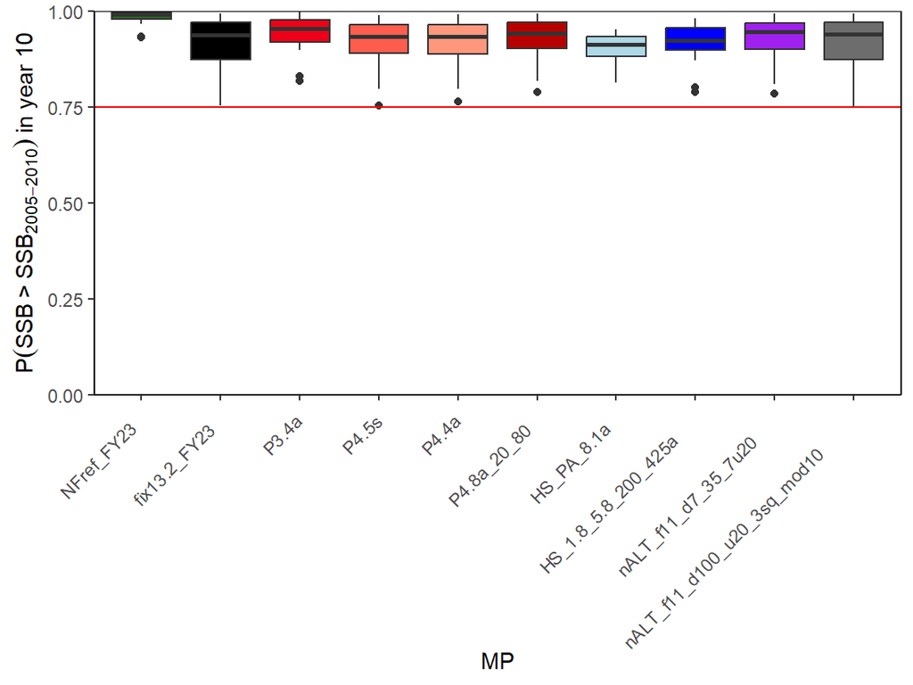

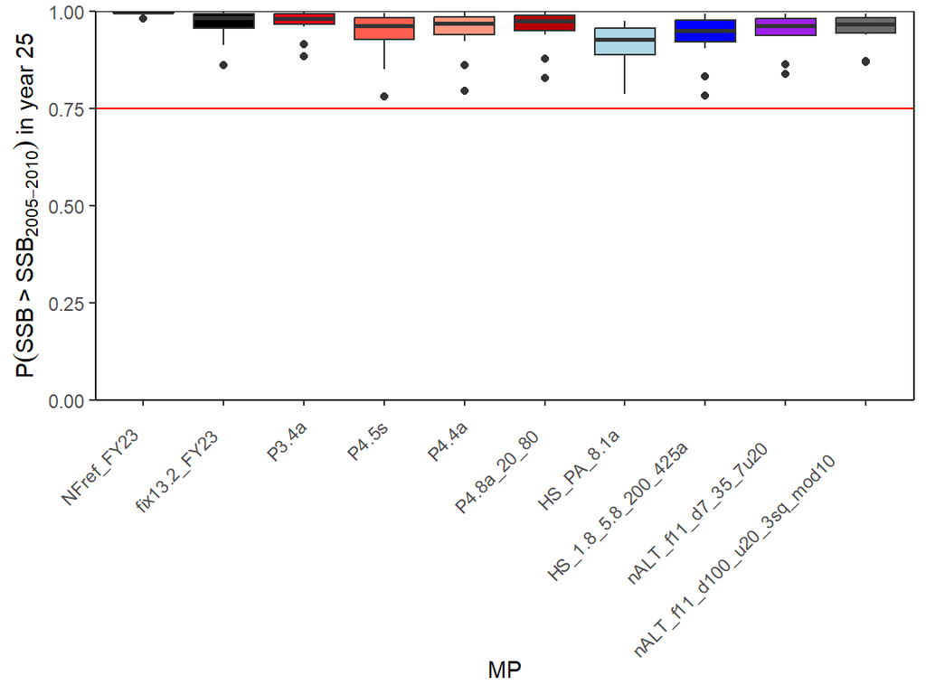

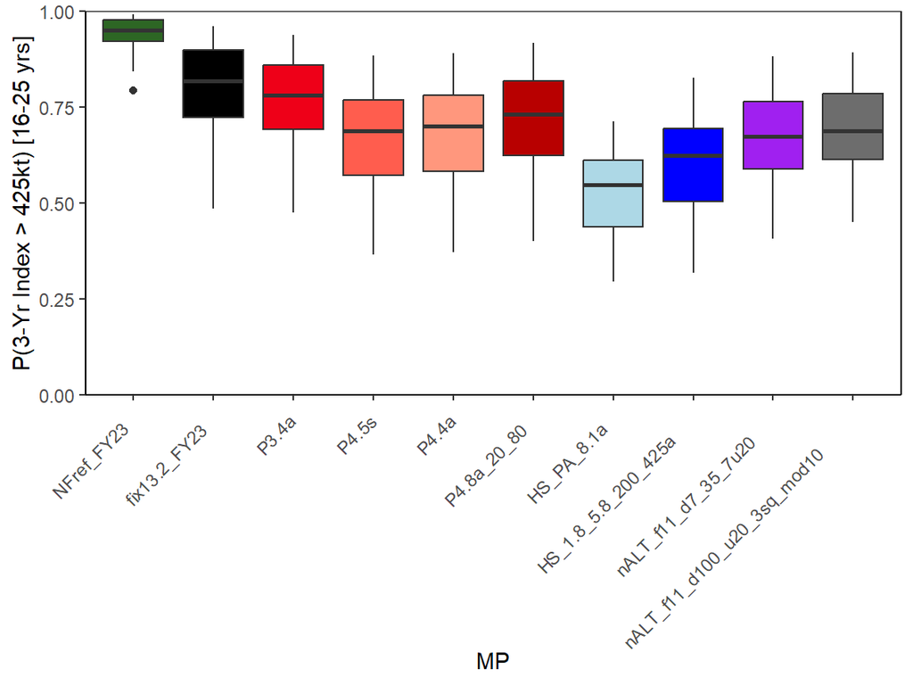

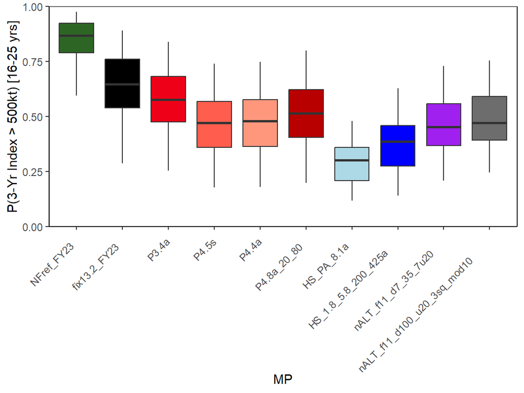

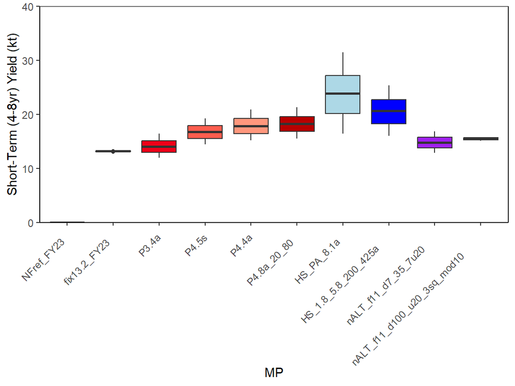

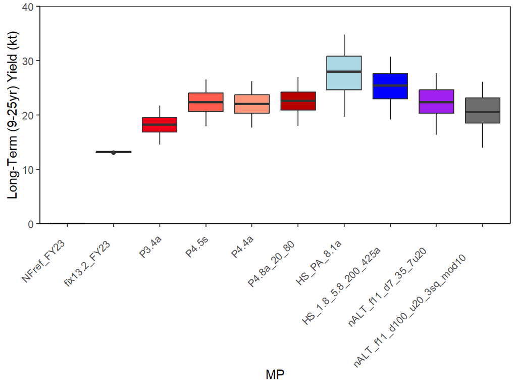

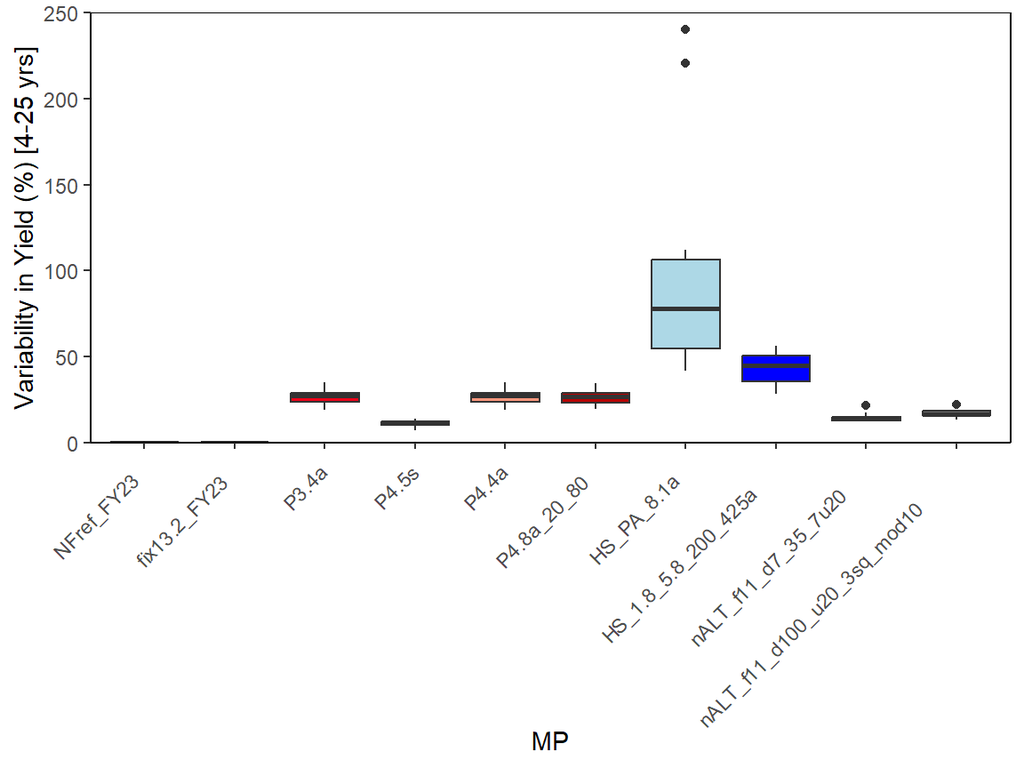

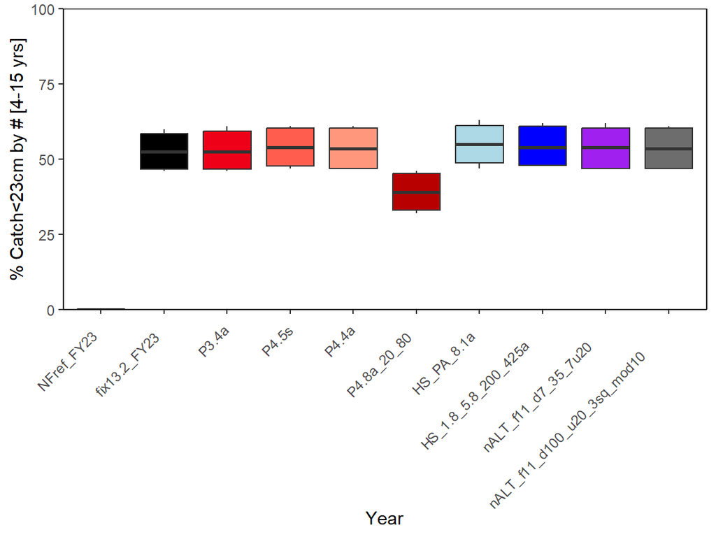